# Series de tiempo 📉📈

> “It is far better to foresee even without certainty than not to foresee at all.” — Henri Poincare

# Prediciendo los pronósticos

La estadística es una ciencia muy joven. El progreso en el análisis de datos y en particular en las series de tiempo siempre ha dependido en gran medida de cuándo, dónde y cómo estaban disponibles los datos y en qué cantidad.

En la época Victoriana un científico llamado Robert FitzRoy fue nombrado jefe de un nuevo departamento del gobierno británico para registrar y publicar datos relacionados con el clima para los marineros. FitRoy había trabajado como capitán del HMS Beagle durante el viaje que llevó a Charles Darwin alrededor del mundo. Este viaje fue instrumental en proporcionar evidencia a Darwin para la teoría de la evolución por selección natural.

Desde el renacimiento, los científicos comenzaron a recopilar datos relacionados con el clima con la ayuda de instrumentos recién inventados, como el barómetro, para medir el estado atmosférico. Esto con el objetivo de emplearlos para la pesca, la agricultura, o la ganadería.

Para *predecir* el clima se analizaba la aparición de nubes o bien el comportamiento de los animales, por ejemplo, el toro en el campo de un granjero, una rana en un frasco, o una golondrina en un arbusto para ver, por ejemplo, si se aproximaba una tormenta.

**Predicción del clima usando ranas**

[figure not shown]

Se modernizaron los barómetros y estos instrumentos los utilizaron para registrar series de tiempo a intervalos diarios o incluso por hora. Los datos se guardaban en diarios privados y libros de registro locales de la ciudad.

[figure not shown]

FitzRoy acuñó el término *pronóstico*. En ese momento, fue criticado por la calidad de sus pronósticos, pero ahora se considera que estaba adelantado a su época. Estableció la costumbre de imprimir pronósticos del tiempo en el periódico *The Times*.

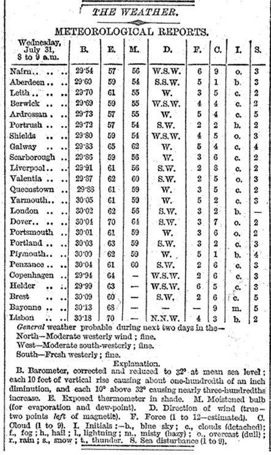

Leer más en: https://www.bbc.com/news/magazine-32483678

```r
library(tidyverse)
library(reshape2)
library(gridExtra)
knitr::opts_chunk$set(comment=NA, fig.align="center")
```

## El despegue de las series de tiempo

Los desarrollos teóricos en el análisis de series de tiempo comenzaron con procesos estocásticos. La primera aplicación real de los modelos que se usan actualmente a los datos comenzó en el trabajo de G. U Yule y J. Walker en las décadas de 1920 y 1930, pero el problema es que no se lograba encontrar una solución de máxima verosimilitud para una clase de modelos más generales.

Tomó hasta 1970 antes de que esto se lograra. En ese momento, salió el clásico libro “Análisis de series temporales” de G. E. P. Box y G. M. Jenkins, que contiene el procedimiento de modelado completo para series individuales: especificación, estimación, diagnóstico y pronóstico.

Hoy en día, los denominados modelos Box-Jenkins son quizás los más utilizados y muchas técnicas utilizadas para la predicción y el ajuste estacional se remontan a estos modelos.

[figure not shown]

### Modelos aditivos

El enfoque de series de tiempo como modelo aditivo es de la siguiente manera. Supongamos que tenemos una serie de tiempo en la cual observamos “ciclos”. A esto normalmente se le llama “descomposición tendencia-ciclo”.

Por lo tanto, pensamos que una serie de tiempo comprende tres componentes: un componente de ciclo de tendencia, un componente estacional y un componente restante (que contiene cualquier otra cosa en la serie de tiempo).

Si suponemos una descomposición aditiva, entonces podemos escribir:

$$y_t = S_t + T_t + R_t$$
donde $y_t$ son los datos, $S_t$ es la compnente estacional, $T_t$ es la componente de tendencia-ciclo, y $R_t$ es la componente de residuo, todos en un periodo $t$.

Alternativamente, una descomposición multiplicativa se escribiría como

$$y_t = S_t \times T_t \times R_t.$$
La descomposición aditiva es la más apropiada si la magnitud de las fluctuaciones estacionales, o la variación alrededor del ciclo de tendencia, no varía con el nivel de la serie temporal. Cuando la variación en el patrón estacional, o la variación alrededor del ciclo de tendencia, parece ser proporcional al nivel de la serie de tiempo, entonces una descomposición multiplicativa es más apropiada. Las descomposiciones multiplicativas son comunes con las series de tiempo económicas.

Una alternativa al uso de una descomposición multiplicativa es transformar primero los datos hasta que la variación en la serie parece ser estable en el tiempo, luego usar una descomposición aditiva. Cuando se ha utilizado una transformación logarítmica, esto es equivalente a usar una descomposición multiplicativa porque

$$y_t=S_t\times T_t \times R_t \quad \mbox{es equivalente a }\quad \mbox{log}(y_t) = \mbox{log}(S_t)+ \mbox{log}(T_t) + \mbox{log}(R_t).$$

### ¿Cómo hacemos análisis de series de tiempo?

Podemos usar el suavizamiento loess para entender y describir el comportamiento de series de tiempo, en las cuales intentamos entender la dependencia de una serie de mediciones indexadas por el tiempo. Típicamente es necesario utilizar distintas *componentes* para describir exitosamente una serie de tiempo, y para esto usamos distintos tipos de suavizamientos. Veremos que distintas *componentes* varían en distintas escalas de tiempo (unas muy lentas, cono la tendencia, otras más rapidamente, como variación quincenal, etc.).

En el siguiente ejemplo consideramos la ventas semanales de un producto a lo largo de 5 años. Veamos que existe una tendencia a largo plazo (crecimientos anuales) y también que existen patrones de variación estacionales.

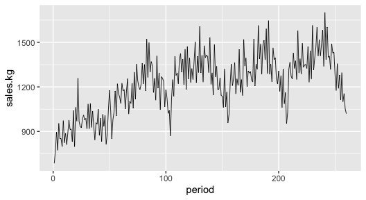

```r
ventas <- read_csv("datos/ventas_semanal.csv")
ggplot(ventas, aes(x = period, y = sales.kg)) + geom_line(size = 0.3)
```

Intentaremos usar suavizamiento para capturar los distintos tipos de variación que observamos en la serie. En primer lugar, si suavizamos poco (por ejemplo $\alpha = 0.1$), vemos que capturamos en parte la tendencia y en parte la variación estacional.

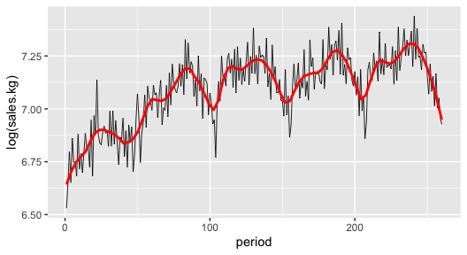

```r
ggplot(ventas, aes(x = period, y = log(sales.kg))) +
  geom_line(size = 0.3) +
  geom_smooth(method = "loess", span = 0.1, se = FALSE, size = 1,
    color = "red")
```

Es mejor comenzar capturando la tendencia, y poco de la componente estacional:

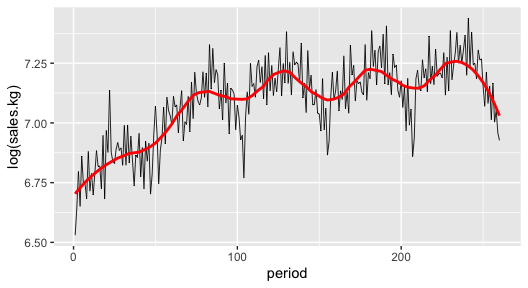

```r
ggplot(ventas, aes(x = period, y = log(sales.kg))) +
  geom_line(size = 0.3) +
  geom_smooth(method = "loess", span = 0.3, se = FALSE, size = 1,
    color = "red")
```

```r
ajuste.trend.1 <- loess(log(sales.kg) ~ period, ventas, span = 0.3)
ventas$trend.1 <- ajuste.trend.1$fitted
ventas$res.trend.1 <- ajuste.trend.1$residuals
```

Ahora calculamos los residuales de este ajuste e intentamos describirlos mediante un suavizamiento más fino. Verificamos que hemos estimado la mayor parte de la tendencia, e intentamos capturar la variación estacional de los residuales.

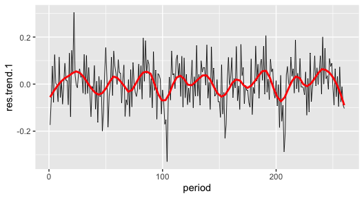

```r
ggplot(ventas, aes(x = period, y = res.trend.1)) +
  geom_line(size = 0.3) +
  geom_smooth(method = "loess", span = 0.15, se = FALSE, size = 1, color = "red")
```

```r
ajuste.est1.1 <- loess(res.trend.1 ~ period, ventas, span = 0.15, degree = 1)
ventas$est1.1 <- ajuste.est1.1$fitted
ventas$res.est1.1 <- ajuste.est1.1$residuals
```

Y graficamos los residuales obtenidos después de ajustar el componente estacional para estudiar la componente de mayor frecuencia.

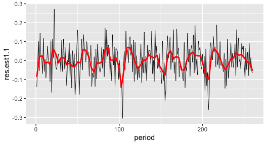

```r
ggplot(ventas, aes(x = period, y = res.est1.1)) +
  geom_line(size = 0.3) +
  geom_smooth(method = "loess", span = 0.06, se = FALSE, size = 1,
    color = "red")
```

```r
ajuste.est2.1 <- loess(res.est1.1 ~ period, ventas, span = 0.06, degree = 1)
ventas$est2.1 <- ajuste.est2.1$fitted
ventas$res.est2.1 <- ajuste.est2.1$residuals
```

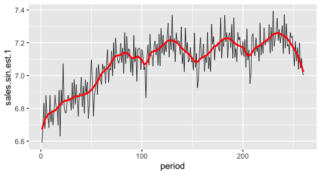

```r
ventas$sales.sin.est.1 <- log(ventas$sales.kg) - ajuste.est1.1$fitted -
  ajuste.est2.1$fitted

ggplot(ventas, aes(x = period, y = sales.sin.est.1)) +
  geom_line(size = 0.3) +
  geom_smooth(method = "loess", span = 0.08, se = FALSE, size = 1, color = "red")
```

```r
ajuste.trend.2 <- loess(sales.sin.est.1 ~ period, ventas, span = 0.08, degree = 1)
ventas$trend.2 <- ajuste.trend.2$fitted
ventas$res.trend.2 <- log(ventas$sales.kg) - ventas$trend.2
```

Y ahora nos concentramos en la componente anual.

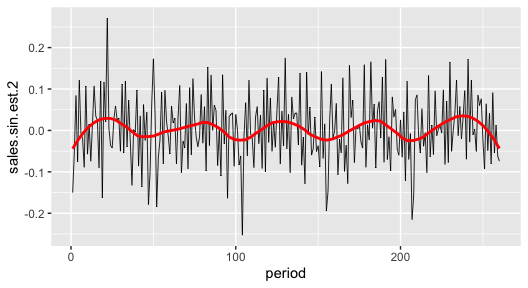

```r
ventas$sales.sin.est.2 <- log(ventas$sales.kg) - ajuste.trend.2$fitted -
  ajuste.est2.1$fitted
ggplot(ventas, aes(x = period, y = sales.sin.est.2)) +
  geom_line(size = 0.3) +
  geom_smooth(method = "loess", span = 0.2, se = FALSE, size = 1, color = "red")
```

```r
ajuste.est1.2 <- loess(sales.sin.est.2 ~ period, ventas, span = 0.15, degree = 1)
ventas$est1.2 <- ajuste.est1.2$fitted
ventas$res.est1.2 <- ajuste.est1.2$residuals
```

Finalmente volvemos a ajustar la componente de frecuencia más alta:

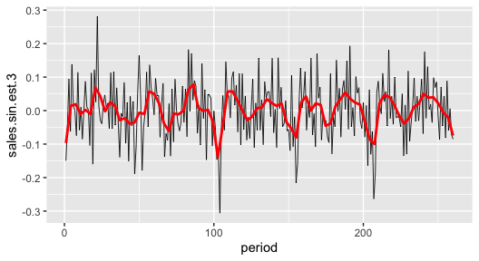

```r
ventas$sales.sin.est.3 <- log(ventas$sales.kg) - ajuste.trend.2$fitted -
  ajuste.est1.2$fitted

ggplot(ventas, aes(x = period, y = sales.sin.est.3)) +
  geom_line(size = 0.3) +
  geom_smooth(method = "loess", span = 0.06, se = FALSE, size = 1,
    color = "red")
```

```r
ajuste.est2.2 <- loess(sales.sin.est.3 ~ period, ventas, span = 0.06, degree = 1)
ventas$est2.2 <- ajuste.est2.2$fitted
ventas$res.est2.2 <- ajuste.est2.2$residuals
```

Verificamos nuestra descomposición y visualizamos el ajuste:

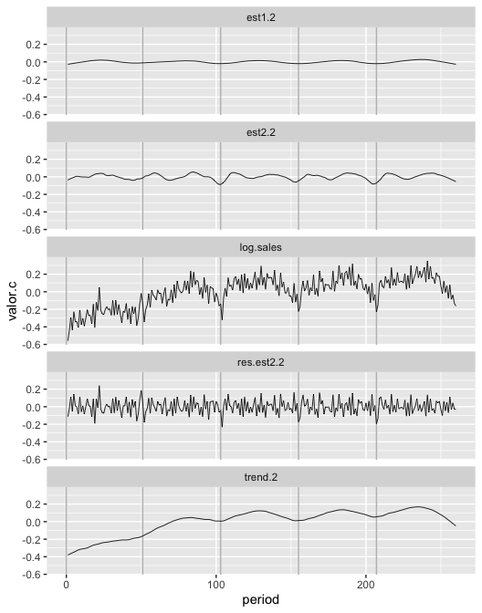

```r
ventas$log.sales <- log(ventas$sales.kg)
ventas.2 <- dplyr::select(ventas, period, trend.2, est1.2, est2.2, res.est2.2,
  log.sales)
#max(abs(apply(ventas.2[, 2:4], 1, sum) - ventas.2$log.sales))

ventas.2.m <- gather(ventas.2, componente, valor, -period)

ventas.2.m.c <- ventas.2.m %>%
  group_by(componente) %>%
  mutate(
    valor.c = valor - mean(valor)
  )

ggplot(ventas.2.m.c, aes(x = period, y = valor.c)) +
  geom_vline(xintercept = c(0, 52 - 1, 52 * 2 - 1, 52 * 3 - 1, 52 * 4 - 1), color = "gray") +
  geom_line(size = 0.3) +
  facet_wrap(~ componente, ncol = 1)
```

Y vemos que es razonable describir los residuales con una distribución normal (con desviación estándar alrededor de 8% sobre el valor ajustado):

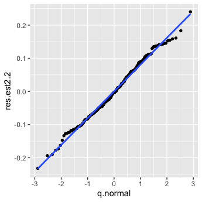

```r
#sd(ventas$res.est2.2)
ventas.ord <- arrange(ventas, res.est2.2)
ventas.ord$q.normal <- qnorm((1:nrow(ventas) - 0.5) / nrow(ventas))
ggplot(ventas.ord, aes(x = q.normal, y = res.est2.2)) +
  geom_point(size = 1.2) +
  geom_smooth(method = "lm")
```

Hay dos cosas que nos falta explicar, en primer lugar, las caídas alrededor de principios/finales de cada año (que son de hasta -0.2), y segundo que esta gráfica parece oscilar demasiado. La estructura que aún no hemos explicado se debe a que las semanas que caen en quincena tienden a tener compras más grandes que las que están justo antes de quincena o fin de mes.

Por el momento detendremos el análisis aquí y explicamos un proceso iterativo para proceder en nuestro análisis exploratorio:

**Iterando ajuste de loess.**

Cuando queremos ajustar con tres componentes: tendencia, estacionalidad y residuales, podemos seguir el siguiente proceso,

1. Ajustar la primera componente a los datos (tendencia).
2. Ajustar la segunda componente a los residuales del paso anterior (estacionalidad).
3. Restar de los datos originales la segunda componente ajustada (estacionalidad).
4. Ajustar a los residuales del paso anterior una nueva componente (tendencia).
5. Restar a los datos originales la componente ajustada en el paso anterior.
6. Ajustar a los residuales del paso anterior una nueva componente (estacionalidad).
7. Checar ajuste y si es necesario iterar de 3 a 6 con las nuevas componentes.

Ahora, si vemos cómo se comportan los residuales según el día donde comienza la semana, vemos el patrón que explicamos antes:

```r
dat.tot <- read_csv(file = "datos/cereal_tot.csv")
ventas.day <- inner_join(ventas,dplyr::select(dat.tot, period, day),by='period')
```

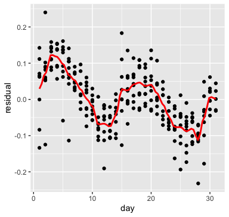

```r
ggplot(ventas.day, aes(x = day, y = res.est2.2)) +
  geom_point() +
  ylab("residual") +
  geom_smooth(method = "loess", span = 0.06, se = FALSE, size = 1, color = "red")
```

Podemos hacer un ajuste loess con estos residuales:

```r
ajuste.quincenas <- loess(res.est2.2 ~ day, data = ventas.day)
ventas$quincena <- ajuste.quincenas$fitted
ventas$res.final <- ajuste.quincenas$residuals
sd(ventas$quincena)
```

```
[1] 0.0430086
```

```r
sd(ventas$res.final)
```

```
[1] 0.06361273
```

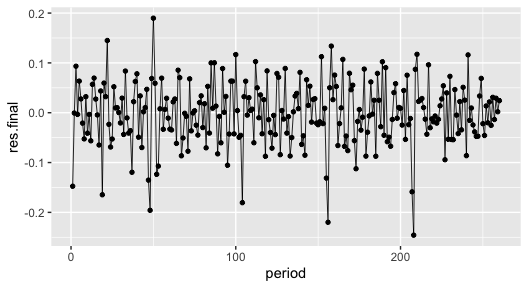

```r
ggplot(ventas, aes(x = period, y = res.final)) +
  geom_line(size = 0.3) +
  geom_point(size = 1.2)
```

```r
ventas.2 <- dplyr::select(ventas, period, trend.2, est1.2, est2.2, quincena,
  res.final, log.sales)
max(abs(apply(ventas.2[, 2:4], 1, sum) - ventas.2$log.sales))
```

```
[1] 0.2401409
```

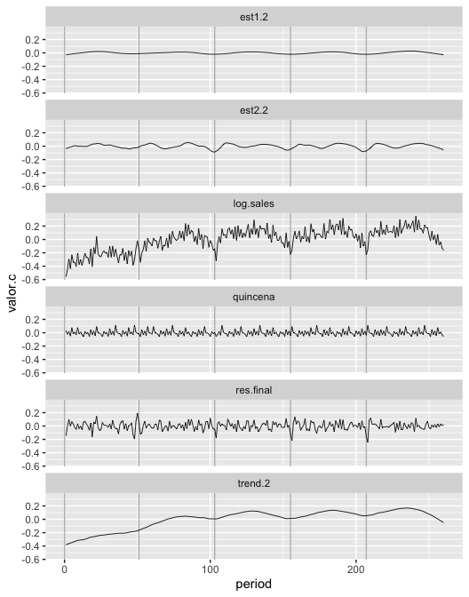

```r
ventas.2.m <- gather(ventas.2, componente, valor, -period)

ventas.2.m.c <- ventas.2.m %>%
  group_by(componente) %>%
  mutate(
    valor.c = valor - mean(valor)
  )

ggplot(ventas.2.m.c, aes(x = period, y = valor.c)) +
  geom_vline(xintercept = c(0, 52 - 1, 52 * 2 - 1, 52 * 3 - 1, 52 * 4 - 1), color = "gray") +
  geom_line(size = 0.3) +
  facet_wrap(~ componente, ncol = 1)
```

```r
library(nullabor)
ventas.res.2 <- dplyr::select(ventas, period, res.final)
ventas.null.2 <- lineup(null_dist(var = 'res.final', dist = 'normal',
  params = list(mean = 0, sd = 0.0636)), n = 20, ventas.res.2)
```

```
decrypt("2CUM 8WhW mH vYVmhmYH EJ")
```

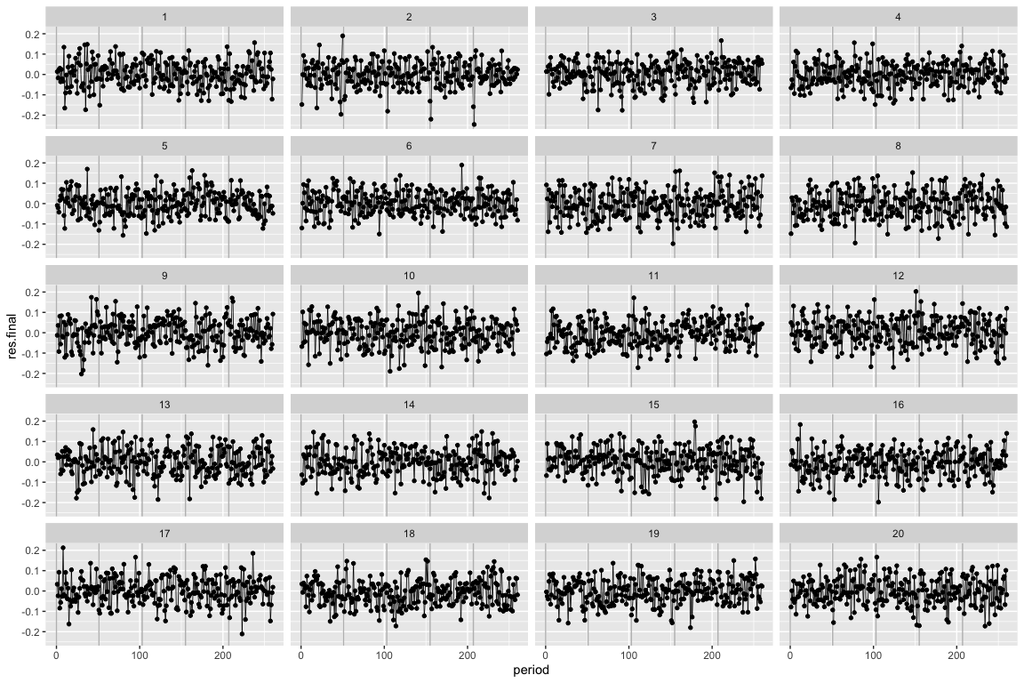

```r
ggplot(ventas.null.2, aes(x = period, y = res.final)) +
  facet_wrap(~ .sample, ncol = 4) +
  geom_line(size = 0.3) +
  geom_vline(xintercept = c(0, 52 - 1, 52 * 2 - 1, 52 * 3 - 1, 52 * 4 - 1),
             color = "gray") +
  geom_point(size = 1.2)
```

### Otro ejemplo de la descomposición clásica

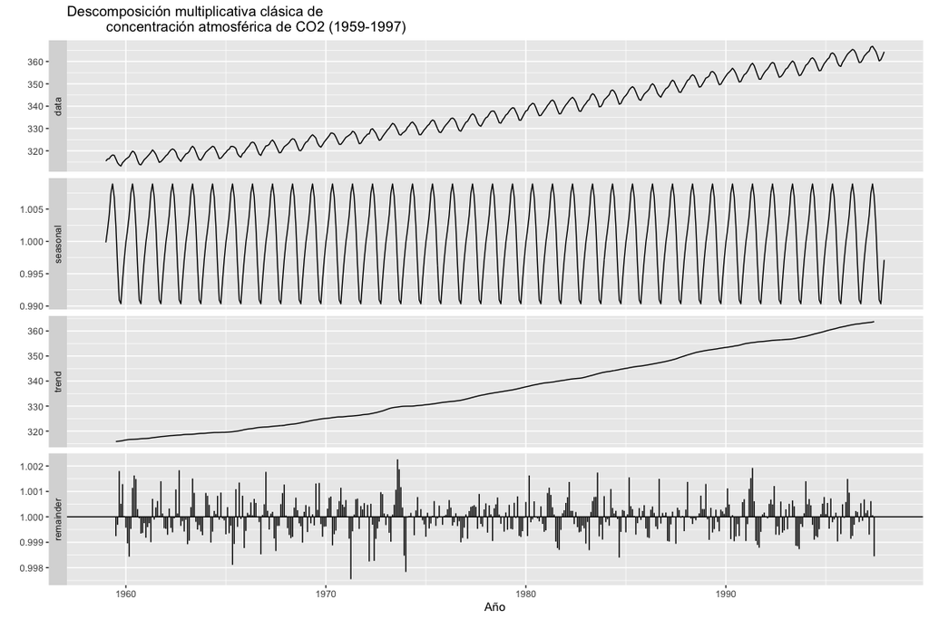

```r
library(forecast)
co2 %>%
  decompose(type = "multiplicative") %>%
  autoplot +
  xlab("Año") +
  ggtitle("Descomposición multiplicativa clásica de
          concentración atmosférica de CO2 (1959-1997)")
```

### Comentarios sobre la descomposición clásica

Si bien la descomposición clásica todavía se usa ampliamente, no se recomienda, ya que ahora hay varios métodos mucho mejores. Algunos de los problemas con la descomposición clásica se resumen a continuación.

- La estimación de la tendencia no está disponible para las primeras y últimas observaciones. Por ejemplo, si $m = 12$, no hay una estimación del ciclo de tendencia para las primeras seis o las últimas seis observaciones. En consecuencia, tampoco existe una estimación del componente restante para los mismos períodos de tiempo.
- La estimación de tendencias (ciclos) tiende a suavizar los aumentos y caídas rápidas en los datos (como se ve en el ejemplo anterior).